# Effect of H3K27me3 depletion on LAD borders

Tom van Schaik

2022-01-31

### Project description

Effect of cohesin looping on genome architecture, from the perspective of the nuclear lamina.

### Introduction

I will prepare the same plots of NL interactions at LAD borders as before, after depletion of CTCF, H3K27me3 and combined.

### Method

Load (z-scale) DamID tracks and plot effect on different types of LAD borders.

### Set-up

Load the libraries and set the parameters.

```r
# Load dependencies
suppressPackageStartupMessages(library(tidyverse))
suppressPackageStartupMessages(library(GenomicRanges))
suppressPackageStartupMessages(library(rtracklayer))
suppressPackageStartupMessages(library(ggplot2))
suppressPackageStartupMessages(library(caTools))
suppressPackageStartupMessages(library(yaml))
suppressPackageStartupMessages(library(M3C))
suppressPackageStartupMessages(library(ggbeeswarm))
suppressPackageStartupMessages(library(broom))
suppressPackageStartupMessages(library(corrr))

bin.size <- "10kb"
damid.dir <- file.path("../results_NQ/normalized/", paste0("bin-", bin.size))

# Prepare output
output.dir <- "ts220121_effect_of_H3K27me3_depletion_on_LAD_borders"
dir.create(output.dir, showWarnings = FALSE)


# Prepare input
input.dir <- "ts220113_CTCF_enrichment_at_LAD_borders"
metadata.borders <- readRDS(file.path(input.dir, "metadata.rds"))
LADs <- readRDS(file.path(input.dir, "LADs.rds"))
LAD.borders <- readRDS(file.path(input.dir, "LAD_borders.rds"))
CTCF.sites <- readRDS(file.path(input.dir, "CTCF_sites.rds"))

LADs <- readRDS(file.path(input.dir, "LADs_pA.rds"))
LAD.borders <- readRDS(file.path(input.dir, "LAD_borders_pA.rds"))

borders <- LAD.borders[["mESC_pA_PT"]]
borders$class <- "xxx"


input.dir <- "ts220121_LAD_changes_after_H3K27me3_depletion"
metadata_h3k27me3 <- readRDS(file.path(input.dir, "metadata_h3k27me3.rds"))
damid_h3k27me3 <- readRDS(file.path(input.dir, "damid_h3k27me3.rds"))
```

Prepare knitr.

```r
library(knitr)
opts_chunk$set(fig.width = 10, fig.height = 4, cache = T,
               message = F, warning = F,
               dev=c('png', 'pdf'), fig.path = file.path(output.dir, "figures/"))
pdf.options(useDingbats = FALSE)
```

Prepare functions.

```r
grMid <- function(gr) {
    start(gr) <- end(gr) <- rowMeans(cbind(start(gr), end(gr)))
    gr
}

DistanceToLADBorder <- function(sites, borders, nearest = T, border.class = F) {
  # Given a GRanges of damid and LAD borders, calculate the
  # distance to the preceding and following LAD. Return a new GRanges

  # Make sure the chromosomes are as they should be - especially for the bins
  sites <- sites[seqnames(sites) %in% c(paste0("chr", 1:22),
                                        "chrX")]
  borders <- borders[seqnames(borders) %in% c(paste0("chr", 1:22),
                                              "chrX")]

  # Preceding distance
  sites$dis.precede <- sites$strand.precede <-
    sites$border.class.precede <- sites$border.ctcf.precede <- NA
  idx.precede <- precede(sites, borders, ignore.strand = T, select = "all")
  sites$dis.precede[queryHits(idx.precede)] <- distance(sites[queryHits(idx.precede)],
                                                        borders[subjectHits(idx.precede)],
                                                        ignore.strand = T)
  sites$strand.precede[queryHits(idx.precede)] <- strand(borders[subjectHits(idx.precede)])

  sites$border.class.precede[queryHits(idx.precede)] <- borders$class[subjectHits(idx.precede)]
  sites$border.ctcf.precede[queryHits(idx.precede)] <- borders$CTCF[subjectHits(idx.precede)]


  # Following distance
  sites$dis.follow <- sites$strand.follow <-
    sites$border.class.follow <- sites$border.ctcf.follow <- NA
  idx.follow <- follow(sites, borders, ignore.strand = T, select = "all")
  sites$dis.follow[queryHits(idx.follow)] <- distance(sites[queryHits(idx.follow)],
                                                      borders[subjectHits(idx.follow)],
                                                      ignore.strand = T)
  sites$strand.follow[queryHits(idx.follow)] <- strand(borders[subjectHits(idx.follow)])

  sites$border.class.follow[queryHits(idx.follow)] <- borders$class[subjectHits(idx.follow)]
  sites$border.ctcf.follow[queryHits(idx.follow)] <- borders$CTCF[subjectHits(idx.follow)]


  # Exception: overlapping (follow = distance (0), precede = NA)
  idx.overlap <- findOverlaps(sites, borders, ignore.strand = T)
  sites$dis.follow[queryHits(idx.overlap)] <- distance(sites[queryHits(idx.overlap)],
                                                       borders[subjectHits(idx.overlap)],
                                                       ignore.strand = T)
  sites$dis.precede[queryHits(idx.overlap)] <- NA
  sites$strand.follow[queryHits(idx.overlap)] <- sites$strand.precede[queryHits(idx.overlap)] <-
    strand(borders[subjectHits(idx.overlap)])

  sites$border.class.precede[queryHits(idx.overlap)] <-
    sites$border.class.follow[queryHits(idx.overlap)] <-
    borders$class[subjectHits(idx.overlap)]
  sites$border.ctcf.precede[queryHits(idx.overlap)] <-
    sites$border.ctcf.follow[queryHits(idx.overlap)] <-
    borders$CTCF[subjectHits(idx.overlap)]


  # Alternative: only use information from the nearest hit
  if (nearest) {
    # Remove precede information if follow is smaller
    idx.remove.precede <- which(sites$dis.follow < sites$dis.precede)
    sites$dis.precede[idx.remove.precede] <- NA
    # Remove follow information if precede is smaller
    idx.remove.follow <- which(sites$dis.follow > sites$dis.precede)
    sites$dis.follow[idx.remove.follow] <- NA
  }

  sites

}

CountPerBins <- function(sites, bin.size = 10000) {

  tib <- as_tibble(mcols(sites)) %>%
    add_column(number = 1:nrow(.)) %>%
    mutate(dis.precede.group = as.numeric(cut(dis.precede,
                                              breaks = seq(0, max(dis.precede, na.rm = T) + 1,
                                                           by = bin.size))) - 1,
           dis.follow.group = as.numeric(cut(dis.follow,
                                             breaks = seq(0, max(dis.follow, na.rm = T) + 1,
                                                          by = bin.size))) - 1) %>%
    dplyr::select(-dis.precede, -dis.follow) %>%
    mutate(dis.precede.group = ifelse(strand.precede == "+",
                                      -dis.precede.group, dis.precede.group),
           dis.follow.group = ifelse(strand.follow == "+",
                                     dis.follow.group, -dis.follow.group)) %>%
    dplyr::select(-strand.precede, -strand.follow) %>%
    gather(key, value, dis.precede.group, dis.follow.group) %>%
    drop_na() %>%
    mutate(border.class = ifelse(key == "dis.precede.group",
                                 border.class.precede, border.class.follow),
           border.ctcf = ifelse(key == "dis.precede.group",
                                 border.ctcf.precede, border.ctcf.follow)) %>%
    dplyr::select(-border.class.precede, -border.class.follow,
           -border.ctcf.precede, -border.ctcf.follow) %>%
    gather(sample, score, -number, -key, -value, -border.class, -border.ctcf) %>%
    group_by(value, border.class, border.ctcf, sample) %>%
    summarise(count = n(),
              mean = mean(score)) %>%
    ungroup() %>%
    mutate(sample = factor(sample, levels = levels(metadata.damid$sample)),
           border.ctcf = factor(border.ctcf, levels = c("nonCTCF", "CTCF")),
           border.class = factor(border.class, levels = c("shared", "unique"))) %>%
    arrange(sample, border.class, border.ctcf)

  tib

}

PlotDamIDScoresAndDifferences <- function(damid.summary,
                                          xlimits = c(-0.4, 0.4),
                                          ylimits.diff = c(-0.3, 0.2),
                                          extra_grouping = NULL) {
  tib <- damid.summary %>%
    mutate(mean = runmean(mean, k = 5)) %>%
    group_by_at(c("sample", "value", extra_grouping)) %>%
    summarise(combined.count = sum(count),
              combined.mean = weighted.mean(mean, count)) %>%
    filter(combined.count > 20) %>%
    separate(sample, c("condition", "timepoint"), remove = F) %>%
    mutate(condition = factor(condition, levels = levels(metadata.damid$condition)),
           timepoint = factor(timepoint, levels = levels(metadata.damid$timepoint))) %>%
    ungroup()

  plt <- tib %>%
    ggplot(aes(x = value / 100, y = combined.mean, col = border.ctcf)) +
      annotate("rect", xmin = 0, xmax = 1e3, ymin = -1, ymax = 5,
               fill = "grey", alpha = 0.3) +
      geom_hline(yintercept = 0, col = "black", linetype = "dashed") +
      geom_vline(xintercept = 0, col = "black", linetype = "dashed") +
      geom_line(size = 1) +
      facet_grid(as.formula(paste(paste(c("condition"),
                                        collapse = " + "),
                                  "~", "timepoint"))) +
      ggtitle("DamID scores at LAD borders") +
      xlab("Distance from LAD border (Mb)") +
      ylab("DamID (z-score)") +
      coord_cartesian(xlim = xlimits, ylim = c(-1, 1)) +
      scale_color_manual(values = c("blue", "red")) +
      theme_bw() +
      theme(aspect.ratio = 1,
            axis.text.x = element_text(angle = 90, hjust = 1))
  plot(plt)

  # Also, plot the difference between 0h and the others
  tib.difference <- tib %>%
    dplyr::select(-sample, -combined.count) %>%
    spread(key = timepoint, value = combined.mean) %>%
    mutate(diff.6h = `6h` - `0h`,
           diff.24h = `24h` - `0h`,
           diff.96h = `96h` - `0h`) %>%
    dplyr::select(-`0h`, -`6h`, -`24h`, -`96h`) %>%
    gather(timepoint, combined.difference, diff.6h, diff.24h, diff.96h) %>%
    mutate(timepoint = factor(timepoint, levels = c("diff.6h", "diff.24h", "diff.96h")))

  plt <- tib.difference %>%
    ggplot(aes(x = value / 100, y = combined.difference, col = border.ctcf)) +
      annotate("rect", xmin = 0, xmax = 1e3, ymin = -1, ymax = 5,
               fill = "grey", alpha = 0.3) +
      geom_hline(yintercept = 0, col = "black", linetype = "dashed") +
      geom_vline(xintercept = 0, col = "black", linetype = "dashed") +
      geom_line(size = 1) +
      facet_grid(as.formula(paste(paste(c("condition"),
                                        collapse = " + "),
                                  "~", "timepoint"))) +
      ggtitle("DamID difference at LAD borders") +
      xlab("Distance from LAD border (Mb)") +
      ylab("DamID difference (z-score)") +
      coord_cartesian(xlim = xlimits, ylim = ylimits.diff) +
      scale_color_manual(values = c("blue", "red")) +
      theme_bw() +
      theme(aspect.ratio = 1,
            axis.text.x = element_text(angle = 90, hjust = 1))
  plot(plt)

  # Also, plot the difference between CTCF and non-CTCF borders
  tib.difference <- tib %>%
    dplyr::select(-sample, -combined.count) %>%
    spread(key = border.ctcf, value = combined.mean) %>%
    mutate(diff = CTCF - nonCTCF) %>%
    dplyr::select(-nonCTCF, -CTCF)

  plt <- tib.difference %>%
    ggplot(aes(x = value / 100, y = diff, col = timepoint)) +
      annotate("rect", xmin = 0, xmax = 1e3, ymin = -1, ymax = 5,
               fill = "grey", alpha = 0.3) +
      geom_hline(yintercept = 0, col = "black", linetype = "dashed") +
      geom_vline(xintercept = 0, col = "black", linetype = "dashed") +
      geom_line(size = 1) +
      facet_wrap( ~ condition, nrow = 2) +
      ggtitle("DamID difference at CTCF borders") +
      xlab("Distance from LAD border (Mb)") +
      ylab("DamID difference (z-score)") +
      coord_cartesian(xlim = xlimits, ylim = ylimits.diff) +
      scale_color_brewer(palette = "Set1") +
      theme_bw() +
      theme(aspect.ratio = 1,
            axis.text.x = element_text(angle = 90, hjust = 1))
  plot(plt)

}
```

### 1. Skipped

NA

### 2. DamID scores at LAD borders

I need to add the distance to LAD border (and which LAD border) to the DamID data. As before, filter LAD borders without active genes.

```r
# Only for borders without genes
borders <- borders[borders$ovl_gene == F]
```

### 3. Individual LAD borders

Prepare distances to LAD borders.

```r
GatherBorders <- function(damid, borders, lads) {

  # Get the distances to the nearest LAD borders for all damid bins
  damid.mid <- damid
  start(damid.mid) <- end(damid.mid) <- (start(damid.mid) + end(damid.mid)) / 2

  dis <- as_tibble(distanceToNearest(damid.mid, borders))

  # Round distances to the nearest 5kb
  dis <- dis %>%
    mutate(distance = ceiling(distance / 5000) * 5000)

  # Also, determine which bins overlap with lads
  ovl <- damid.mid %over% lads

  # Process data as tibble
  tib <- as_tibble(damid.mid) %>%
    add_column(border_idx = dis$subjectHits,
               border_ctcf = borders$CTCF[dis$subjectHits],
               border_ctcf_strand = borders$CTCF_strand[dis$subjectHits],
               distance = dis$distance,
               within_lad = ovl) %>%
    mutate(distance = case_when(within_lad == 1 ~ distance,
                                T ~ -distance),
           border_ctcf = factor(border_ctcf,
                                       levels = c("nonCTCF", "CTCF")),
           border_ctcf_strand = factor(border_ctcf_strand,
                                       levels = c("nonCTCF",
                                                  "outwards", "inwards",
                                                  "ambiguous"))) %>%
    filter(abs(distance) < 2e5)

  # # Only work with "complete" borders (remove small iLADs / LADs)
  # borders_complete <- which(as.numeric(table(tib$border_idx)) > 25)
  #
  # tib <- tib %>%
  #   filter(border_idx %in% borders_complete)

  # Plot all lines as "test"
  tib %>%
    ggplot(aes(x = distance / 1e3, y = PT_0h)) +
    #geom_line(aes(group = border_idx), alpha = 0.1) +
    geom_smooth(aes(group = border_ctcf, col = border_ctcf), se = T) +
    xlab("Distance to LAD border (kb)") +
    ylab("pA-DamID (z-score)") +
    theme_bw() +
    theme(aspect.ratio = 1)

  tib

}

tib_damid <- GatherBorders(damid_h3k27me3, borders = borders,
                           lads = LADs[["mESC_pA_PT"]])
```

I will create a few plots that possibly capture the effects of CTCF depletion in combination with H3K27me3 inhibition.

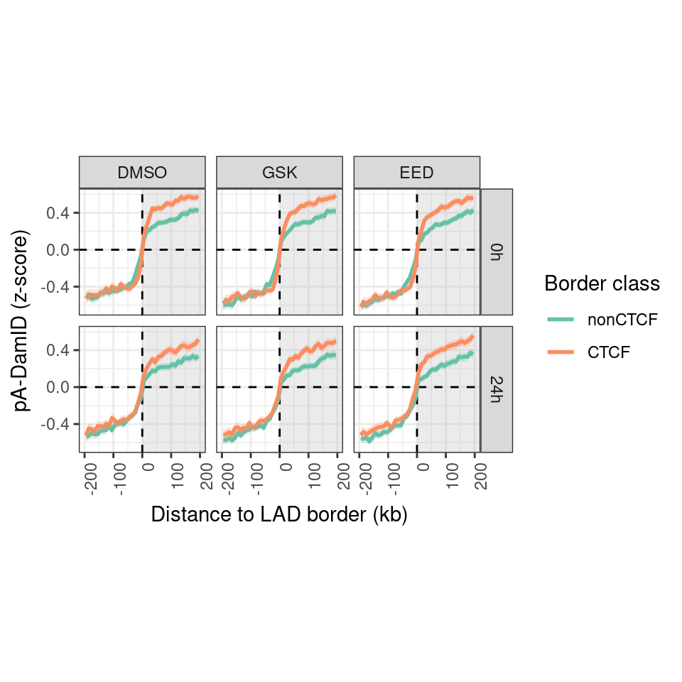

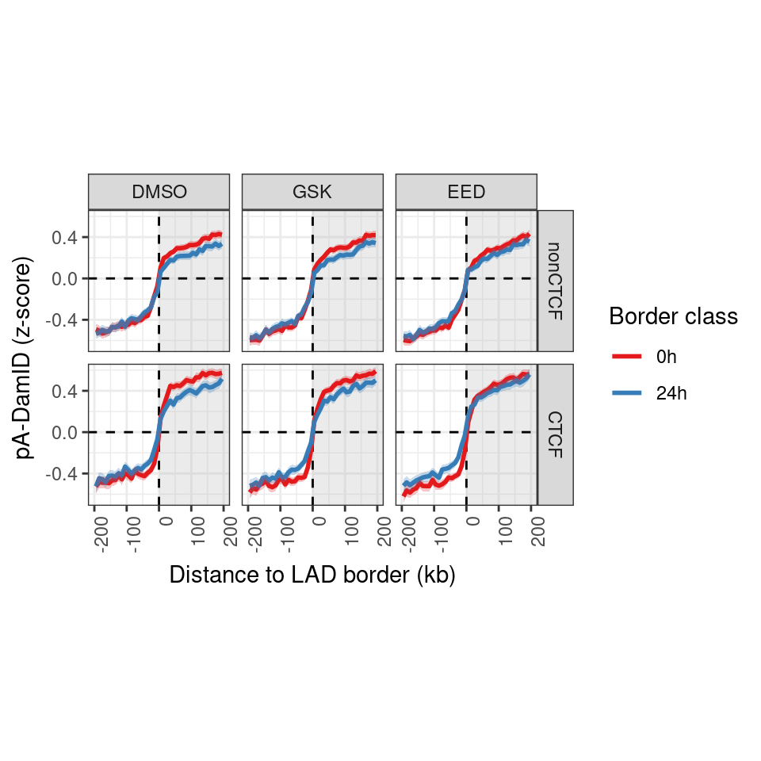

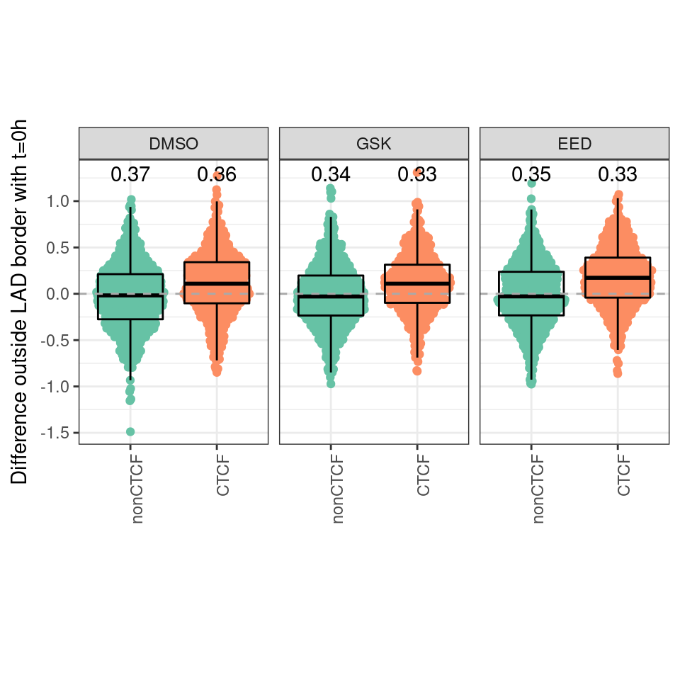

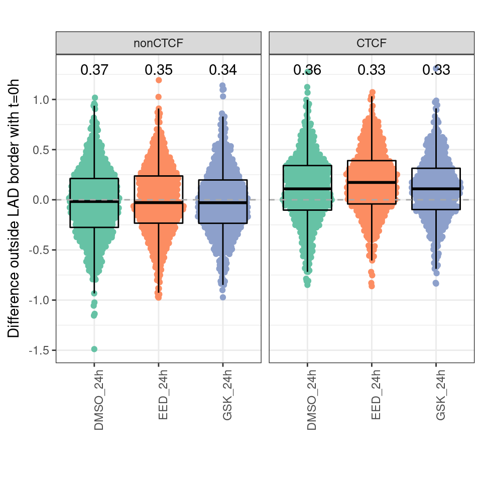

```
## # A tibble: 6 × 5
##   group   key        pvalue     padj sign
##   <fct>   <chr>       <dbl>    <dbl> <lgl>
## 1 nonCTCF DMSO_24h 8.74e- 2 2.62e- 1 FALSE
## 2 nonCTCF EED_24h  7.93e- 1 7.93e- 1 FALSE
## 3 nonCTCF GSK_24h  9.42e- 2 2.62e- 1 FALSE
## 4 CTCF    DMSO_24h 6.69e-10 2.68e- 9 TRUE
## 5 CTCF    EED_24h  9.35e-23 5.61e-22 TRUE
## 6 CTCF    GSK_24h  4.31e-11 2.15e-10 TRUE
## # A tibble: 3 × 5
##   group condition   pvalue     padj sign
##   <chr> <chr>        <dbl>    <dbl> <lgl>
## 1 CTCF  DMSO      5.87e- 9 5.87e- 9 TRUE
## 2 CTCF  GSK       1.17e- 9 2.33e- 9 TRUE
## 3 CTCF  EED       3.67e-15 1.10e-14 TRUE
```

```r
sd_fun <- function(x, y = 1.3) {
  return(data.frame(y = y, label = round(sd(x), 2)))
}

PlotBordersWithConfidenceIntervals <- function(tib, samples,
                                               ylim = c(-0.65, 0.6),
                                               smooth = 1,
                                               group = "border_ctcf",
                                               filter_96h = T) {

  if (filter_96h) {
    samples <- samples[! grepl("96h", samples)]
  }

  # Gather tib
  if (smooth != 1) {
    tib <- tib %>%
      mutate_at(vars(ends_with("h")), runmean, k = smooth, endrule = "mean")
  }

  tib_gather <- tib %>%
    gather(key, value,
           all_of(samples)) %>%
    mutate(idx = match(key, metadata_h3k27me3$sample),
           condition = metadata_h3k27me3$condition[idx],
           timepoint = metadata_h3k27me3$timepoint[idx])
  tib_gather$group <- tib_gather %>% pull(group)


  # Plot some tracks
  plt <- tib_gather %>%
    filter(key %in% samples) %>%
    ggplot(aes(x = distance / 1e3, y = value,
               group = group, col = group, fill = group)) +
    annotate("rect", xmin = 0, xmax = Inf, ymin = -Inf, ymax = Inf,
             fill = "grey", alpha = 0.3) +
    geom_hline(yintercept = 0, col = "black", linetype = "dashed") +
    geom_vline(xintercept = 0, col = "black", linetype = "dashed") +
    #geom_line(aes(group = border_idx), alpha = 0.1) +
    #geom_smooth(aes(group = border_ctcf, col = border_ctcf), se = T) +
    stat_summary(fun = mean, geom = "line", size = 1) +
    stat_summary(fun.data = mean_se, geom = "ribbon", alpha = 0.25, col = NA,
                 fun.args = list(mult = 1.96)) +
    #facet_grid(. ~ key) +
    facet_grid(timepoint ~ condition) +
    xlab("Distance to LAD border (kb)") +
    ylab("pA-DamID (z-score)") +
    coord_cartesian(xlim = c(-200, 200), ylim = ylim) +
    scale_color_brewer(palette = "Set2", name = "Border class") +
    scale_fill_brewer(palette = "Set2", name = "Border class", guide = "none") +
    theme_bw() +
    theme(aspect.ratio = 1,
          axis.text.x = element_text(angle = 90, hjust = 1))
  plot(plt)

  plt <- tib_gather %>%
    filter(key %in% samples) %>%
    ggplot(aes(x = distance / 1e3, y = value,
               group = timepoint, col = timepoint, fill = timepoint)) +
    annotate("rect", xmin = 0, xmax = Inf, ymin = -Inf, ymax = Inf,
             fill = "grey", alpha = 0.3) +
    geom_hline(yintercept = 0, col = "black", linetype = "dashed") +
    geom_vline(xintercept = 0, col = "black", linetype = "dashed") +
    #geom_line(aes(group = border_idx), alpha = 0.1) +
    #geom_smooth(aes(group = border_ctcf, col = border_ctcf), se = T) +
    stat_summary(fun = mean, geom = "line", size = 1) +
    stat_summary(fun.data = mean_se, geom = "ribbon", alpha = 0.25, col = NA,
                 fun.args = list(mult = 1.96)) +
    #facet_grid(. ~ key) +
    facet_grid(group ~ condition) +
    xlab("Distance to LAD border (kb)") +
    ylab("pA-DamID (z-score)") +
    coord_cartesian(xlim = c(-200, 200), ylim = ylim) +
    scale_color_brewer(palette = "Set1", name = "Border class") +
    scale_fill_brewer(palette = "Set1", name = "Border class", guide = "none") +
    theme_bw() +
    theme(aspect.ratio = 1,
          axis.text.x = element_text(angle = 90, hjust = 1))
  plot(plt)


  # Can I also quantify the difference between the local CTCF depletion?
  samples_without_pt <- samples

  tib_ctcf <- tib %>%
    filter(distance > -20e3 & distance < 0) %>%
    dplyr::select(border_idx, all_of(samples_without_pt), all_of(group)) %>%
    dplyr::rename_at(vars(group), ~ "group") %>%
    group_by(border_idx, group) %>%
    summarise_at(samples_without_pt, mean, na.rm = T) %>%
    ungroup() %>%
    mutate(DMSO_24h = DMSO_24h - DMSO_0h,
           GSK_24h = GSK_24h - GSK_0h,
           EED_24h = EED_24h - EED_0h) %>%
    dplyr::select(border_idx, group,
                  contains("24h")) %>%
    gather(key, value, -group, -border_idx) %>%
    mutate(idx = match(key, metadata_h3k27me3$sample),
           condition = metadata_h3k27me3$condition[idx],
           timepoint = metadata_h3k27me3$timepoint[idx],
           group = factor(group, levels = c("nonCTCF",
                                            "CTCF",
                                            "outwards", "inwards", "ambiguous")))

  # Plot by time point
  plt <- tib_ctcf %>%
    ggplot(aes(x = group, y = value, col = group)) +
    geom_quasirandom() +
    geom_boxplot(fill = NA, col = "black", outlier.shape = NA) +
    stat_summary(fun.data = sd_fun, geom = "text", col = "black") +
    geom_hline(yintercept = 0, col = "darkgrey", linetype = "dashed") +
    facet_grid(. ~ condition) +
    scale_color_brewer(palette = "Set2", guide = F) +
    xlab("") +
    ylab("Difference outside LAD border with t=0h") +
    theme_bw() +
    theme(aspect.ratio = 1.5,
          axis.text.x = element_text(angle = 90, hjust = 1))
  plot(plt)

  # Plot by border class
  plt <- tib_ctcf %>%
    ggplot(aes(x = key, y = value, col = key)) +
    geom_quasirandom() +
    geom_boxplot(fill = NA, col = "black", outlier.shape = NA) +
    stat_summary(fun.data = sd_fun, geom = "text", col = "black") +
    geom_hline(yintercept = 0, col = "darkgrey", linetype = "dashed") +
    facet_grid(. ~ group) +
    scale_color_brewer(palette = "Set2", guide = F) +
    xlab("") +
    ylab("Difference outside LAD border with t=0h") +
    theme_bw() +
    theme(aspect.ratio = 1.5,
          axis.text.x = element_text(angle = 90, hjust = 1))
  plot(plt)

  # Statistics - difference from diff = 0
  tib_ctcf %>%
    group_by(group, key) %>%
    dplyr::summarise(pvalue = wilcox.test(value)$p.value) %>%
    ungroup() %>%
    mutate(padj = p.adjust(pvalue),
           sign = padj < 0.05) %>%
    print(n = 40)

  # Statistics - difference with nonCTCF borders
  tib_stat <- tibble()

  for (current_group in levels(tib_ctcf$group)) {
    for (current_condition in levels(tib_ctcf$condition)) {

      if (! current_group %in% tib_ctcf$group) next
      if (current_group %in% "nonCTCF") next
      if (! current_condition %in% tib_ctcf$condition) next


      tmp <- wilcox.test(tib_ctcf %>%
                           filter(group == current_group &
                                    condition == current_condition) %>%
                           pull(value),
                         tib_ctcf %>%
                           filter(group == "nonCTCF" &
                                    condition == current_condition) %>%
                           pull(value))

      tib_stat <- bind_rows(tib_stat,
                            tibble(group = current_group,
                                   condition = current_condition,
                                   pvalue = tmp$p.value))
    }
  }

  tib_stat %>%
    mutate(padj = p.adjust(pvalue),
           sign = padj < 0.05) %>%
    print(n = 40)

  tib_stat

}

# CTCF vs non-CTCF
tib_stat <- tibble()

tmp <- PlotBordersWithConfidenceIntervals(tib_damid,
                                   c("DMSO_0h", "DMSO_24h",
                                     "GSK_0h", "GSK_24h",
                                     "EED_0h", "EED_24h"))
```

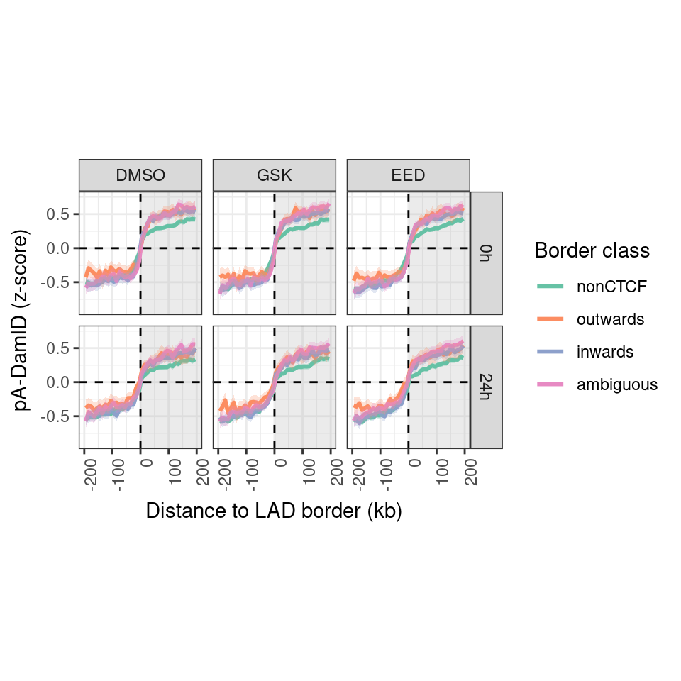

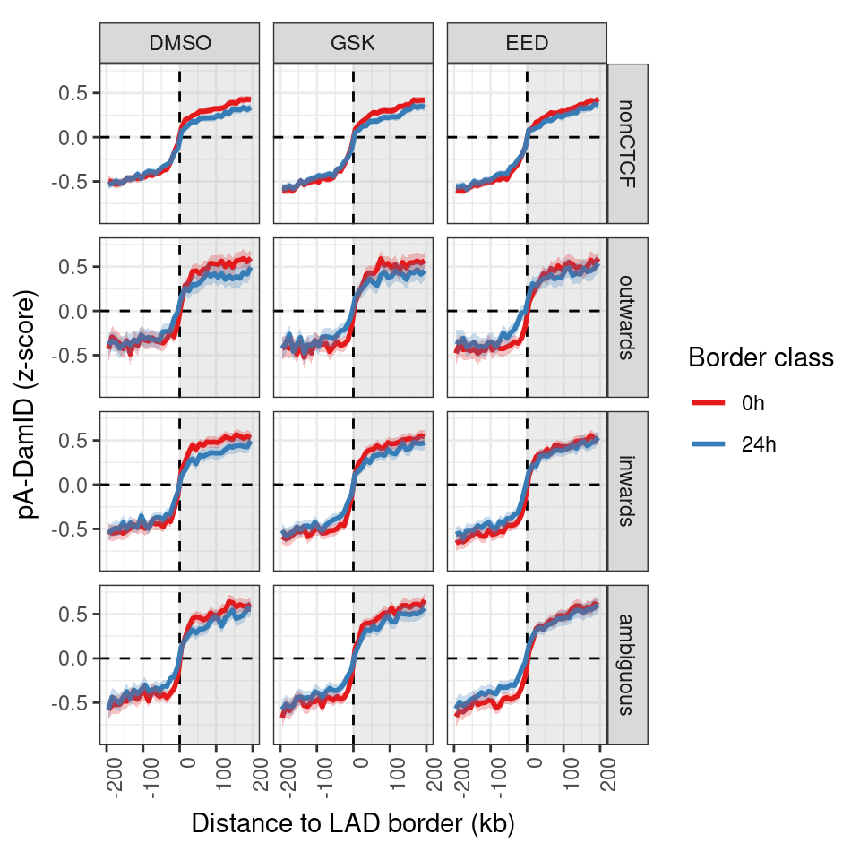

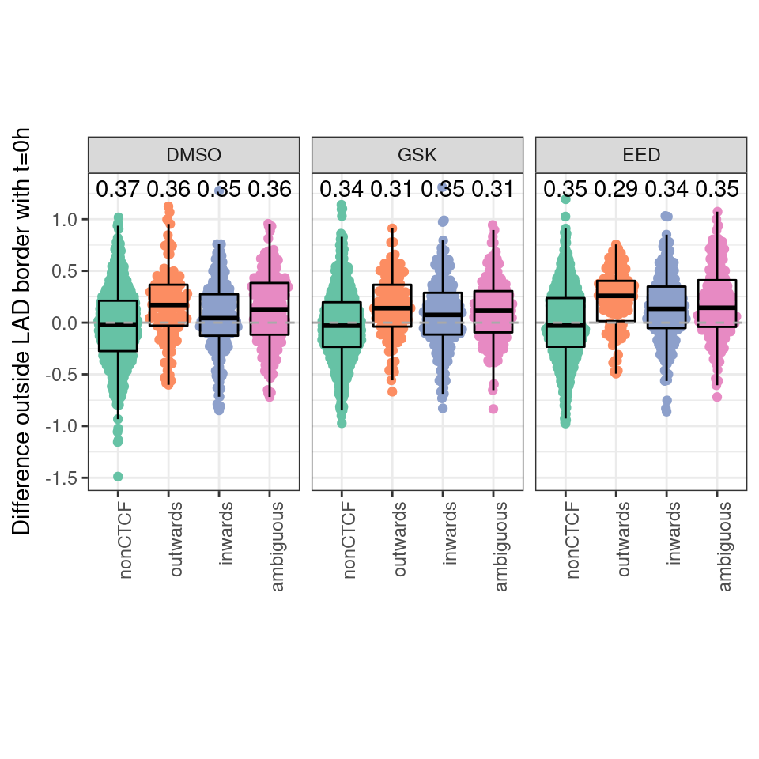

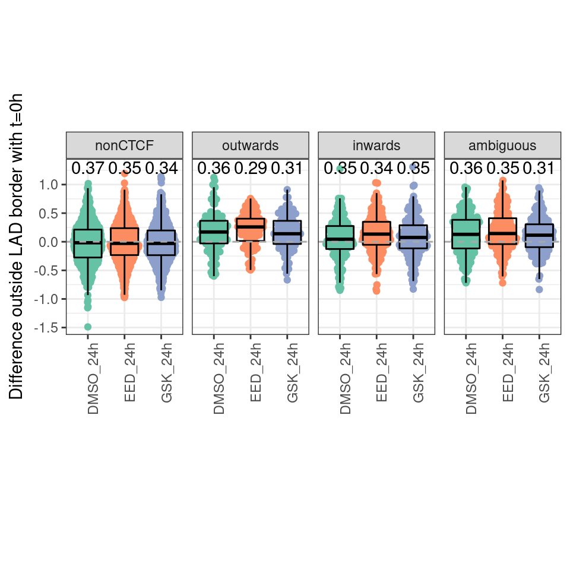

```
## # A tibble: 12 × 5
##    group     key             pvalue         padj sign
##    <fct>     <chr>            <dbl>        <dbl> <lgl>
##  1 nonCTCF   DMSO_24h 0.0874        0.262        FALSE
##  2 nonCTCF   EED_24h  0.793         0.793        FALSE
##  3 nonCTCF   GSK_24h  0.0942        0.262        FALSE
##  4 outwards  DMSO_24h 0.0000335     0.000201     TRUE
##  5 outwards  EED_24h  0.00000000594 0.0000000653 TRUE
##  6 outwards  GSK_24h  0.0000104     0.0000834    TRUE
##  7 inwards   DMSO_24h 0.0126        0.0504       FALSE
##  8 inwards   EED_24h  0.000000102   0.00000102   TRUE
##  9 inwards   GSK_24h  0.00461       0.0231       TRUE
## 10 ambiguous DMSO_24h 0.0000218     0.000153     TRUE
## 11 ambiguous EED_24h  0.00000000254 0.0000000305 TRUE
## 12 ambiguous GSK_24h  0.00000834    0.0000751    TRUE
## # A tibble: 9 × 5
##   group     condition        pvalue         padj sign
##   <chr>     <chr>             <dbl>        <dbl> <lgl>
## 1 outwards  DMSO      0.00000465    0.0000139    TRUE
## 2 outwards  GSK       0.00000193    0.0000118    TRUE
## 3 outwards  EED       0.00000000223 0.0000000201 TRUE
## 4 inwards   DMSO      0.00333       0.00333      TRUE
## 5 inwards   GSK       0.000955      0.00191      TRUE
## 6 inwards   EED       0.00000168    0.0000118    TRUE
## 7 ambiguous DMSO      0.00000262    0.0000131    TRUE
## 8 ambiguous GSK       0.00000288    0.0000131    TRUE
## 9 ambiguous EED       0.0000000184  0.000000147  TRUE
```

```r
# tib_stat <- bind_rows(tib_stat, tmp)
#
# tib_stat %>%
#   mutate(padj = p.adjust(pvalue),
#            sign = padj < 0.05) %>%
#   print(n = 40)



# CTCF + orientation vs non-CTCF
tib_stat <- tibble()

tmp <- PlotBordersWithConfidenceIntervals(tib_damid,
                                   c("DMSO_0h", "DMSO_24h",
                                     "GSK_0h", "GSK_24h",
                                     "EED_0h", "EED_24h"),
                                   group = "border_ctcf_strand",
                                   ylim = c(-0.9, 0.75))
```

```r
tib_stat <- bind_rows(tib_stat, tmp)

tib_stat %>%
  mutate(padj = p.adjust(pvalue),
           sign = padj < 0.05) %>%
  print(n = 40)
```

```
## # A tibble: 9 × 5
##   group     condition        pvalue         padj sign
##   <chr>     <chr>             <dbl>        <dbl> <lgl>
## 1 outwards  DMSO      0.00000465    0.0000139    TRUE
## 2 outwards  GSK       0.00000193    0.0000118    TRUE
## 3 outwards  EED       0.00000000223 0.0000000201 TRUE
## 4 inwards   DMSO      0.00333       0.00333      TRUE
## 5 inwards   GSK       0.000955      0.00191      TRUE
## 6 inwards   EED       0.00000168    0.0000118    TRUE
## 7 ambiguous DMSO      0.00000262    0.0000131    TRUE
## 8 ambiguous GSK       0.00000288    0.0000131    TRUE
## 9 ambiguous EED       0.0000000184  0.000000147  TRUE
```

The results are very clear: CTCF depletion results in a local gain of NL interactions outside LADs. H3K27me3 inhibition has no effect on NL interactions at LAD borders / within LADs.

### 4. Save data

No data to save.

### Conclusion

H3K27me3 inhibition does not affect LAD border positioning, alone or in combination with CTCF depletion. CTCF depletion by itself still has the same effects.